# Hyne Trial : Green Board Data

Jonathan Harrington

Tuesday, Septemeber 8, 2014

# 1 Hyne: Green Board Data

## 1.1 Todo

- grab a lot more example data for comparison
- why is MOE=6.50 over-represented? DONE
- check that ecoustic MOE is based on $\rho v^2$ rather than some empirical correlation.
- classify boards as cant or side

## 1.2 Background

### 1.2.1 Trimmer

Green board shape could not be collected. USNR software crashed whenever writing shape data to disk enabled.

Data collected USNR database on TRIMMER2.

### 1.2.2 SICK Camera

Power was lost briefly around 11:40a (someone tripped over the power cord?). drive

(see `sick.Rmd`)

### 1.2.3 Ecoustic

Ecoustic data collected as csv file copied from Ecoustic2 PC by ML.

Loaded into HYNE database using `ecoustic-create.sql` and `ecoustic2db.py`.

## 1.3 Ecoustic Dataset

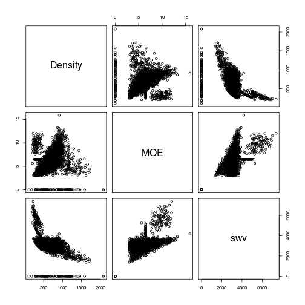

```r
library(lattice)
library(RODBC)
ch = odbcConnect("HYNE", "sa", "password12")
E = sqlQuery(ch, "select Timestamp, ScheduledDimensions, Width, Thickness, Length, Weight, Density, MOE from ecoustic")
E$swv = sqrt(E$MOE/E$Density * 1e+09)
E$f1 = E$swv/2/E$Length
# pairs(E[,3:10])
pairs(E[, 7:9])
```

Board properties:

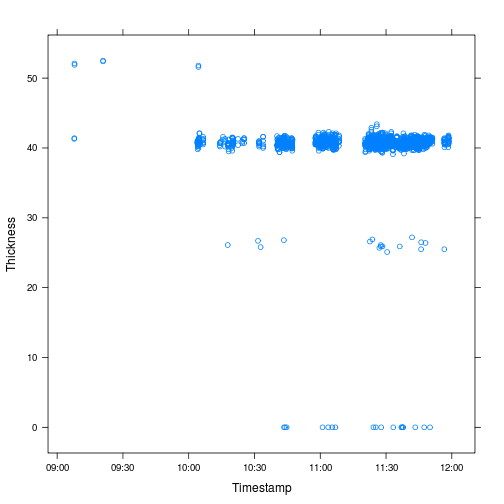

```r
xyplot(Thickness ~ Timestamp, E)
```

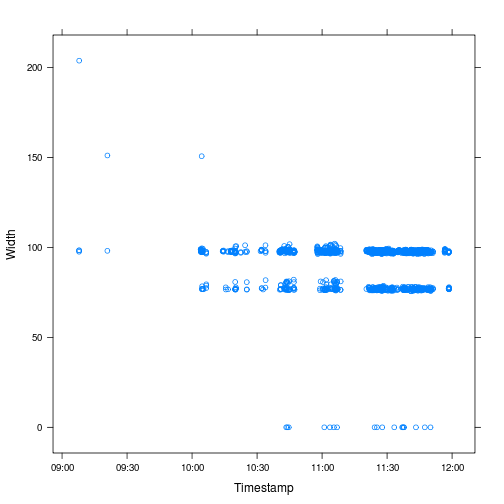

```r
xyplot(Width ~ Timestamp, E)
```

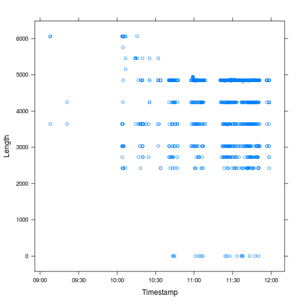

```r
xyplot(Length ~ Timestamp, E)
```

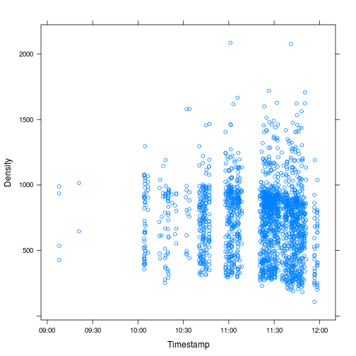

```r
xyplot(Density ~ Timestamp, E)
```

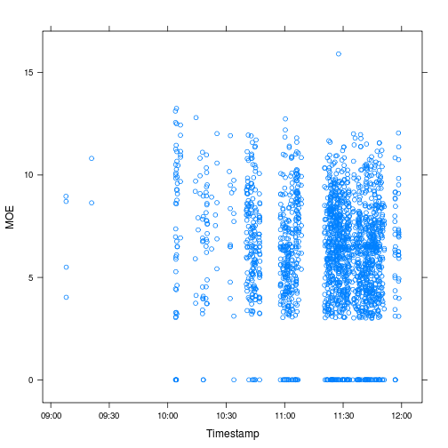

```r
xyplot(MOE ~ Timestamp, E)
```

```r
# summary(lm(MOE ~ ScaledMOE, E)) # MOE = ScaledMOE
```

What does Length=Thickness=Width=0 denote? All have Grade='Not graded'.

Where does the board dimension data come from? The Trimmer2 scanner? Yes, via PLC (not db).

```r
sum(E$Length == 0)  # 18 length=width=thickness=0
```

```
## [1] 18
```

```r
sum(E$Density <= 0)  # 0
```

```
## [1] NA
```

```r
sum(E$Weight <= 0)  # 0
```

```
## [1] 0
```

```r
sum(E$MOE == 0)  # 122
```

```
## [1] 122
```

```r
E$MOE[E$Length == 0]  # always 0
```

```
##  [1] 0 0 0 0 0 0 0 0 0 0 0 0 0 0 0 0 0 0
```

```r
E$MOE[E$Width == 0]  # always 0
```

```
##  [1] 0 0 0 0 0 0 0 0 0 0 0 0 0 0 0 0 0 0
```

```r
E[E$MOE == 6.5, ]  # nothing unusual
```

```
##                Timestamp ScheduledDimensions Width Thickness Length Weight
## 45   2014-08-31 10:04:50         100x38x7000  98.1      41.3   2425   5.23
## 47   2014-08-31 10:04:56          75x38x7000  76.8      42.1   2425   3.89
## 119  2014-08-31 10:32:03         100x38x7000  98.7      40.8   4850   9.34
## 120  2014-08-31 10:32:04         100x38x7000  98.6      41.0   4850   9.19
## 152  2014-08-31 10:40:48         100x38x7000  97.8      40.7   3637   4.66
## 181  2014-08-31 10:41:54         100x38x7000  98.5      40.7   4850   6.05
## 265  2014-08-31 10:44:50         100x38x7000  98.5      40.7   4850   6.12
## 305  2014-08-31 10:47:09         100x38x7000  98.3      41.2   4850  10.34
## 307  2014-08-31 10:47:11         100x38x7000  97.6      40.7   4850   8.86
## 320  2014-08-31 10:57:46         100x38x7000  97.1      40.7   4243  17.19
## 325  2014-08-31 10:57:50         100x38x7000  98.1      41.4   4850  11.86
## 365  2014-08-31 10:59:15         100x38x7000  98.7      40.7   4921   6.32
## 390  2014-08-31 11:00:13         100x38x7000  97.7      41.0   4850   8.32
## 405  2014-08-31 11:00:23         100x38x7000  98.3      40.7   4850   8.12
```

[output cut: 113 more lines]

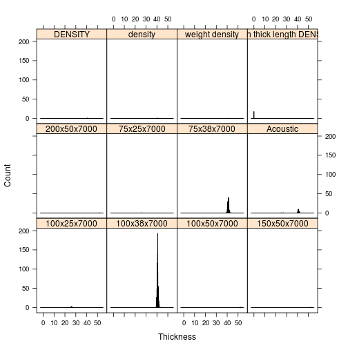

```r
histogram(~Thickness | ScheduledDimensions, E, nint = 1000, type = "count")
```

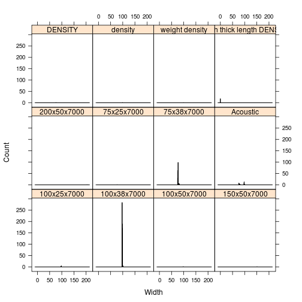

```r
histogram(~Width | ScheduledDimensions, E, nint = 1000, type = "count")
```

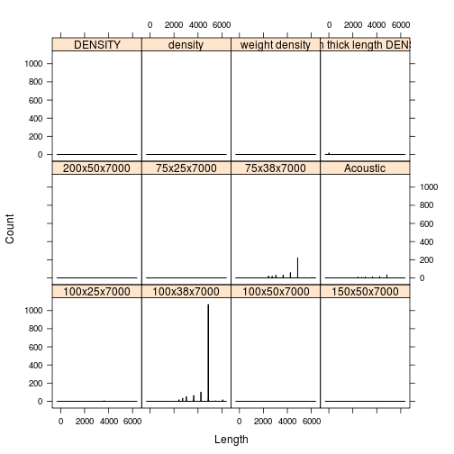

```r
histogram(~Length | ScheduledDimensions, E, nint = 1000, type = "count")
```

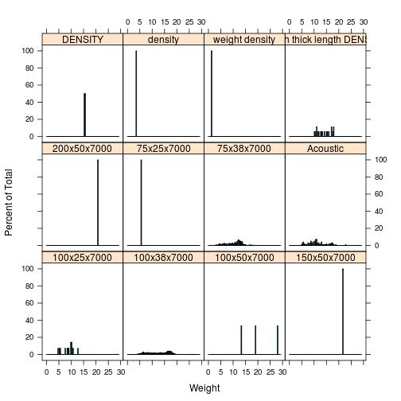

```r
histogram(~Weight | ScheduledDimensions, E, nint = 100)
```

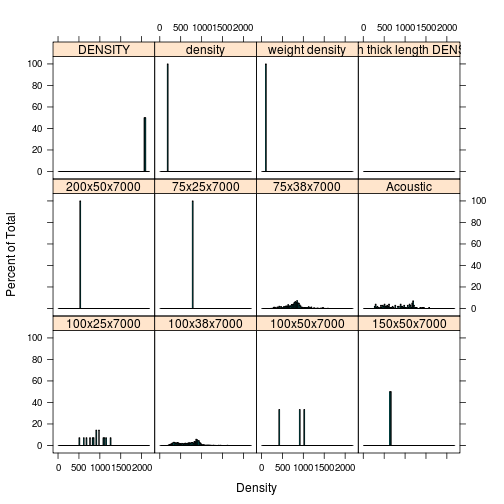

```r
histogram(~Density | ScheduledDimensions, E, nint = 100)
```

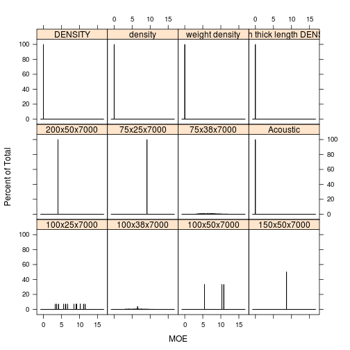

```r
histogram(~MOE | ScheduledDimensions, E, nint = 10001)
```

~6% of boards have densities>1100 kg/m^3, these are considered unreasonable (a fully saturated board of basic density 500 kg/m^3 has a green density of 1166 kg/m^3).

Why does MOE=6.50 occur way more often than it should?

> On the question below there are some cases where 6.5 MoE is assumed. It happens when the confidence in the velocity is low (~50%) but the mill wanted a conservative approach (don’t throw potentially good boards out) so 6.5 is assigned. The real MoE could be above or below that. One reason the confidence could be low on trimmer line 2 is that there can be some bouncing of the test boards away from the hammer when the next large board hits the fence after the trimmer. There is no record in the file of which boards had low confidence.